# تمرین کامپیوتری پنجم - Neural Networks and Deep Learning

# قسمت اول(پیاده سازی شبكه Feed Forward با استفاده از کتابخانه Numpy)

# نیما مدیرکیاسرایی 810198471

## هدف پروژه

در این پروژه قرار است یک شبکه عصبی FeedForward از پایه و با استفاده از کتابخانه numpy بسازیم. این شبکه قرار است بر اساس این ویژگی ها و با ساختن ترکیبات غیرخطی از آنها، وزن اتصالات بین لایه ها و پارامترهایش را طوری تنظیم کند، که خروجی آن ضمن داشتن کمترین خطا، کلاس تصویر ورودی متناظر را به درستی پیشبینی کند.

# بخش اول : بررسی و پیش پردازش داده

```python
import pandas as pd
import numpy as np
import matplotlib.pyplot as plt
import copy
from sklearn.metrics import accuracy_score
from sklearn.utils import shuffle
from sklearn.preprocessing import OneHotEncoder
```

```python
x_train = pd.read_csv('AI-CA5-Dataset/TrainImgs.csv',header = None)
x_test = pd.read_csv('AI-CA5-Dataset/TestImgs.csv',header = None)
y_train = pd.read_csv('AI-CA5-Dataset/TrainLabels.csv',header = None)
y_test = pd.read_csv('AI-CA5-Dataset/TestLabels.csv',header = None)
```

# 1

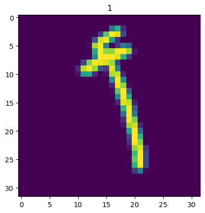

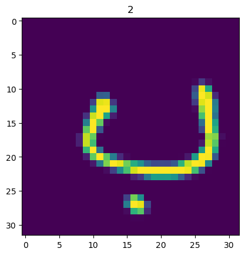

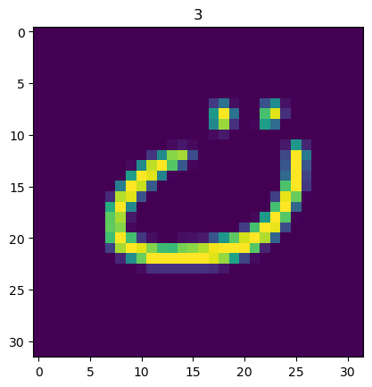

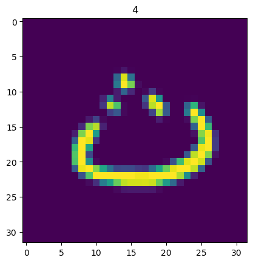

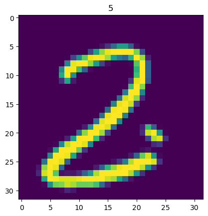

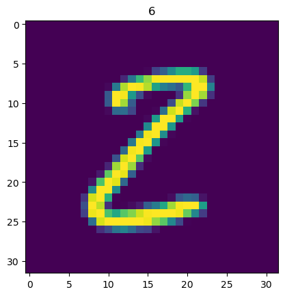

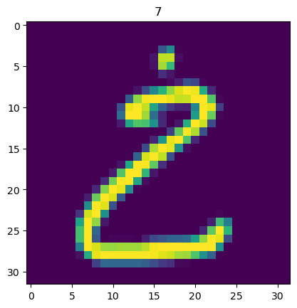

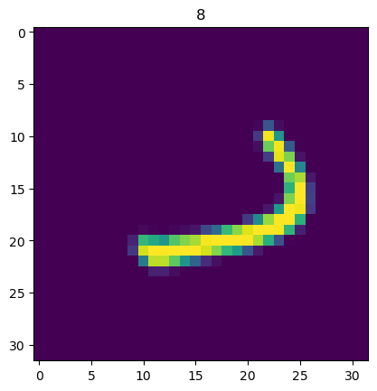

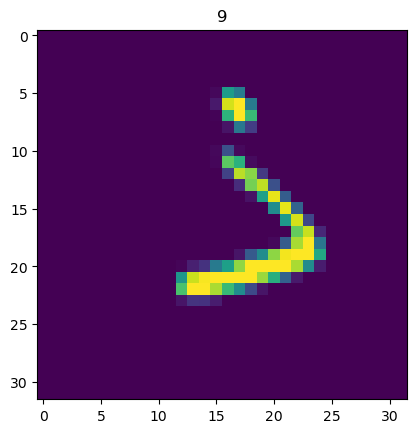

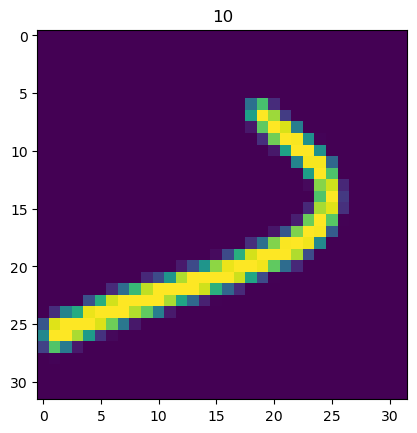

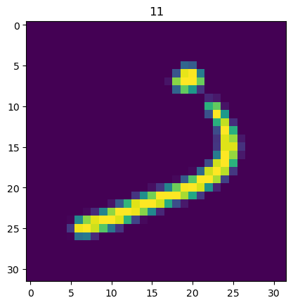

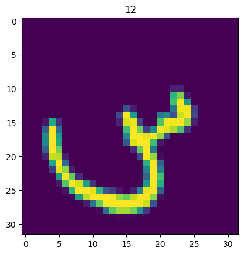

[16 more figures not shown]

```python
for label in range(1,29):
    index = y_train[y_train[0] == label].index[0]
    img = x_train.iloc[index].to_numpy().reshape(32,32)
    plt.imshow(img.T)
    plt.title(label)
    plt.show()
```

# 2

مقدار هر پیکسل عددی بین 0 و 255 می باشد.

```python
print(min(x_train.iloc[0]))
print(max(x_train.iloc[0]))
```

```
0
255
```

# 3

تعداد داده های ترین و تست :

```python
print('train:',len(x_train))
print('test:',len(x_test))
```

```
train: 13440
test: 3360
```

تعداد کلاس های موجود :

```python
len(y_train[0].unique())
```

```
28
```

# 4

```python
indecies_train = []
for i in range(1,17):
    indecies_train = indecies_train +(y_train[y_train[0] == i].index.to_list())
x_train = x_train.iloc[indecies_train]
y_train = y_train.iloc[indecies_train]
```

```python
indecies_test = []
for i in range(1,17):
    indecies_test = indecies_test +(y_test[y_test[0] == i].index.to_list())
x_test = x_test.iloc[indecies_test]
y_test = y_test.iloc[indecies_test]
```

```python
x_train
```

|  | 0 | 1 | 2 | 3 | 4 | 5 | 6 | 7 | 8 | 9 | ... | 1014 | 1015 | 1016 | 1017 | 1018 | 1019 | 1020 | 1021 | 1022 | 1023 |
| --- | --- | --- | --- | --- | --- | --- | --- | --- | --- | --- | --- | --- | --- | --- | --- | --- | --- | --- | --- | --- | --- |
| 0 | 0 | 0 | 0 | 0 | 0 | 0 | 0 | 0 | 0 | 0 | ... | 0 | 0 | 0 | 0 | 0 | 0 | 0 | 0 | 0 | 0 |
| 1 | 0 | 0 | 0 | 0 | 0 | 0 | 0 | 0 | 0 | 0 | ... | 0 | 0 | 0 | 0 | 0 | 0 | 0 | 0 | 0 | 0 |
| 2 | 0 | 0 | 0 | 0 | 0 | 0 | 0 | 0 | 0 | 0 | ... | 0 | 0 | 0 | 0 | 0 | 0 | 0 | 0 | 0 | 0 |
| 3 | 0 | 0 | 0 | 0 | 0 | 0 | 0 | 0 | 0 | 0 | ... | 0 | 0 | 0 | 0 | 0 | 0 | 0 | 0 | 0 | 0 |
| 4 | 0 | 0 | 0 | 0 | 0 | 0 | 0 | 0 | 0 | 0 | ... | 0 | 0 | 0 | 0 | 0 | 0 | 0 | 0 | 0 | 0 |
| ... | ... | ... | ... | ... | ... | ... | ... | ... | ... | ... | ... | ... | ... | ... | ... | ... | ... | ... | ... | ... | ... |
| 13339 | 0 | 0 | 0 | 0 | 0 | 0 | 0 | 0 | 0 | 0 | ... | 0 | 0 | 0 | 0 | 0 | 0 | 0 | 0 | 0 | 0 |
| 13340 | 0 | 0 | 0 | 0 | 0 | 0 | 0 | 0 | 0 | 0 | ... | 0 | 0 | 0 | 0 | 0 | 0 | 0 | 0 | 0 | 0 |
| 13341 | 0 | 0 | 0 | 0 | 0 | 0 | 0 | 0 | 0 | 0 | ... | 0 | 0 | 0 | 0 | 0 | 0 | 0 | 0 | 0 | 0 |
| 13342 | 0 | 0 | 0 | 0 | 0 | 0 | 0 | 0 | 0 | 0 | ... | 0 | 0 | 0 | 0 | 0 | 0 | 0 | 0 | 0 | 0 |
| 13343 | 0 | 0 | 0 | 0 | 0 | 0 | 0 | 0 | 0 | 0 | ... | 0 | 0 | 0 | 0 | 0 | 0 | 0 | 0 | 0 | 0 |

7680 rows × 1024 columns

# 5

```python
y_train.value_counts()
```

```
1     480
2     480
3     480
4     480
5     480
6     480
7     480
8     480
9     480
10    480
11    480
12    480
13    480
14    480
15    480
16    480
dtype: int64
```

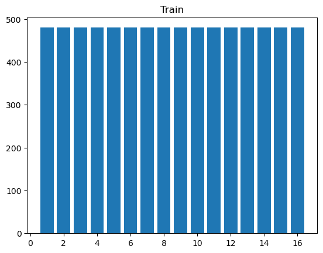

```python
plt.bar(y_train[0].unique(),y_train.value_counts().to_list())
plt.title('Train')
plt.show()
```

```python
y_test.value_counts()
```

```
1     120
2     120
3     120
4     120
5     120
6     120
7     120
8     120
9     120
10    120
11    120
12    120
13    120
14    120
15    120
16    120
dtype: int64
```

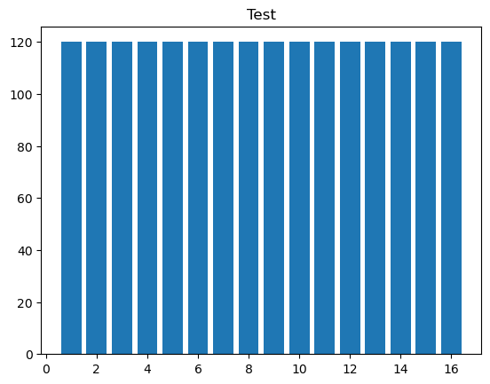

```python
plt.bar(y_test[0].unique(),y_test.value_counts().to_list())
plt.title('Test')
plt.show()
```

# 6

اگر داده ها را scale نکنیم با بازه بزرگی از اعداد(بین 0 و 255) سر و کار داریم و باعث می شود آموزش به خوبی انجام نشود و دقت مدل پایین بیاید. با انجام دادن این کار بازه اعداد بین 0 و 1 محدود می شود و به دقت خوبی میرسیم.

```python
x_train = x_train / 255
x_test = x_test / 255
```

# 7

هر داده ای که عددی نباشد کیفی یا categorical است. برای مدلسازی حتما باید داده ها به صورت عددی باشند. برای مثال رنگ، رشته تحصیلی، وضعیت زندگی همگی categorical هستند. برای آن که از نظر الگوریتم اعداد برتری نسبت به هم نداشته باشند از One-Hot Encoding استفاده می کنیم. با انجام این کار میتوانیم پاسخ اصلی(واقعی) را با پاسخ لایه آخر شبکه تطابق دهیم. در این روش هر نورون در لایه آخر متناظر با یک ستون از لیبل ها است و می توانیم به ازای هر دیتا، خروجی لایه آخر را با پاسخ اصلی مقایسه کنیم.

```python
one_hot_train_labels = pd.get_dummies(y_train[0])
one_hot_test_labels = pd.get_dummies(y_test[0])
```

```python
one_hot_train_labels
```

|  | 1 | 2 | 3 | 4 | 5 | 6 | 7 | 8 | 9 | 10 | 11 | 12 | 13 | 14 | 15 | 16 |
| --- | --- | --- | --- | --- | --- | --- | --- | --- | --- | --- | --- | --- | --- | --- | --- | --- |
| 0 | 1 | 0 | 0 | 0 | 0 | 0 | 0 | 0 | 0 | 0 | 0 | 0 | 0 | 0 | 0 | 0 |
| 1 | 1 | 0 | 0 | 0 | 0 | 0 | 0 | 0 | 0 | 0 | 0 | 0 | 0 | 0 | 0 | 0 |
| 2 | 1 | 0 | 0 | 0 | 0 | 0 | 0 | 0 | 0 | 0 | 0 | 0 | 0 | 0 | 0 | 0 |
| 3 | 1 | 0 | 0 | 0 | 0 | 0 | 0 | 0 | 0 | 0 | 0 | 0 | 0 | 0 | 0 | 0 |
| 4 | 1 | 0 | 0 | 0 | 0 | 0 | 0 | 0 | 0 | 0 | 0 | 0 | 0 | 0 | 0 | 0 |
| ... | ... | ... | ... | ... | ... | ... | ... | ... | ... | ... | ... | ... | ... | ... | ... | ... |
| 13339 | 0 | 0 | 0 | 0 | 0 | 0 | 0 | 0 | 0 | 0 | 0 | 0 | 0 | 0 | 0 | 1 |
| 13340 | 0 | 0 | 0 | 0 | 0 | 0 | 0 | 0 | 0 | 0 | 0 | 0 | 0 | 0 | 0 | 1 |
| 13341 | 0 | 0 | 0 | 0 | 0 | 0 | 0 | 0 | 0 | 0 | 0 | 0 | 0 | 0 | 0 | 1 |
| 13342 | 0 | 0 | 0 | 0 | 0 | 0 | 0 | 0 | 0 | 0 | 0 | 0 | 0 | 0 | 0 | 1 |
| 13343 | 0 | 0 | 0 | 0 | 0 | 0 | 0 | 0 | 0 | 0 | 0 | 0 | 0 | 0 | 0 | 1 |

7680 rows × 16 columns

```python
one_hot_test_labels
```

|  | 1 | 2 | 3 | 4 | 5 | 6 | 7 | 8 | 9 | 10 | 11 | 12 | 13 | 14 | 15 | 16 |
| --- | --- | --- | --- | --- | --- | --- | --- | --- | --- | --- | --- | --- | --- | --- | --- | --- |
| 0 | 1 | 0 | 0 | 0 | 0 | 0 | 0 | 0 | 0 | 0 | 0 | 0 | 0 | 0 | 0 | 0 |
| 1 | 1 | 0 | 0 | 0 | 0 | 0 | 0 | 0 | 0 | 0 | 0 | 0 | 0 | 0 | 0 | 0 |
| 56 | 1 | 0 | 0 | 0 | 0 | 0 | 0 | 0 | 0 | 0 | 0 | 0 | 0 | 0 | 0 | 0 |
| 57 | 1 | 0 | 0 | 0 | 0 | 0 | 0 | 0 | 0 | 0 | 0 | 0 | 0 | 0 | 0 | 0 |
| 112 | 1 | 0 | 0 | 0 | 0 | 0 | 0 | 0 | 0 | 0 | 0 | 0 | 0 | 0 | 0 | 0 |
| ... | ... | ... | ... | ... | ... | ... | ... | ... | ... | ... | ... | ... | ... | ... | ... | ... |
| 3223 | 0 | 0 | 0 | 0 | 0 | 0 | 0 | 0 | 0 | 0 | 0 | 0 | 0 | 0 | 0 | 1 |
| 3278 | 0 | 0 | 0 | 0 | 0 | 0 | 0 | 0 | 0 | 0 | 0 | 0 | 0 | 0 | 0 | 1 |
| 3279 | 0 | 0 | 0 | 0 | 0 | 0 | 0 | 0 | 0 | 0 | 0 | 0 | 0 | 0 | 0 | 1 |
| 3334 | 0 | 0 | 0 | 0 | 0 | 0 | 0 | 0 | 0 | 0 | 0 | 0 | 0 | 0 | 0 | 1 |
| 3335 | 0 | 0 | 0 | 0 | 0 | 0 | 0 | 0 | 0 | 0 | 0 | 0 | 0 | 0 | 0 | 1 |

1920 rows × 16 columns

# بخش دوم : تکمیل بخش های ناقص شبکه عصبی

# Dataloader

```python
class Dataloader:
    '''
    This class prepares the dataset for the neural network.
    '''

    def __init__(self, data, labels, n_classes, batch_size=None, shuffle=False):
        '''
        This is the constructor. It gets dataset information and initializes the
        Dataloader class fields.
            Parameters:
                data: features your dataset in pandas.Dataframe format.
                labels: labels of your dataset in pandas.Dataframe format.
                n_classes: number of classes you have in your dataset.
                batch_size: the number of samples that will be propagated through the network.
                shuffle: boolean value indicating whether or not the dataset should be shuffled
        '''

        assert len(data)==len(labels)
        self.__n_classes = n_classes
        self.__batch_size = batch_size
        self.__shuffle = shuffle
        self.__data = data
        self.__onehot_labels = self.__onehot(labels, self.__n_classes)

    def __onehot(self, labels, n_classes):
        '''
        This private method gets labels and provides one_hot vectors of labels.
        For categorical variables where no such ordinal relationship exists,
        the integer encoding is not enough.
        In this case, a one-hot encoding can be applied to the integer representation.
        This is where the integer encoded variable is removed, and a new binary variable is
        added for each unique integer value.
        example:
            red,    green,    blue
            1,      0,        0
            0,      1,        0
            0,      0,        1
                Parameters:
                        label: lables of your dataset in pandas.Dataframe format.
                        n_classes: number of classes you have in your dataset.

                Returns:
                    onehot_vectors: onehot vectors of the labels
        '''
        # TODO: Implement
#         onehot_vectors = np.eye(n_classes)[labels-1]
        onehot_vectors = pd.get_dummies(labels[0]).to_numpy()
        return onehot_vectors

    def __shuffle_dataset(self):
        '''
        This private method shuffles your dataset.
        It uses data and onehot_labels to shuffle them
        symmetrical.
        '''
        # TODO: Implement
        self.__data, self.__onehot_labels = shuffle(self.__data, self.__onehot_labels)

    def __iter__(self):
        '''
        The __iter__() function returns an iterator for the
        given object (array, set, tuple, etc., or custom objects).
        This will return your dataset in the batch_size given. This should
        be used to provide data for the neural network.
        '''

        if self.__shuffle:
            self.__shuffle_dataset()

        if self.__batch_size==None:
            yield (np.matrix(self.__data), np.matrix(self.__onehot_labels))
            return

        for idx in range(0, len(self.__data), self.__batch_size):
            yield (np.matrix(self.__data[idx:idx+self.__batch_size]),
                   np.matrix(self.__onehot_labels[idx:idx+self.__batch_size]))
```

# Activation Functions

```python
class Identical:
    '''
    This is the Identical activation function. This activation function just
    return the value it gets.
    '''

    def __init__(self): pass


    def __val(self, matrix):
        '''
        This private method gets a matrix and uses the activity function on that.
        As this is an identical activity function, it just
        returns np.matrix of the input.

            Parameters:
                matrix: np.matrix of values
            Returns:
                identical_value: np.matrix of input with float datatypes
        '''
        identical_value = np.matrix(matrix, dtype=float)
        return identical_value

    def derivative(self, matrix):
        '''
        This method returns the derivation of the input.
        As the derivation of x is one, this method returns
        a matrix of one with the shape of the input matrix.

            Parameters:
                matrix: np.matrix of values
            Returns:
                identical_derivative: np.matrix of ones with matrix shape
        '''
        temp = np.matrix(matrix, dtype=float)
        identical_derivative = np.matrix(np.full(np.shape(temp), 1.))
        return identical_derivative

    def __call__(self, matrix):
        '''
        __call__ is a special function in Python that, when implemented inside a class,
        gives its instances (objects) the ability to behave like a function.
        Here we return the _value method output.

            Parameters:
                matrix: np.matrix of values
            Returns:
                __val(matrix): __val return value for the input matrix
        '''
        return self.__val(matrix)
```

```python
class Relu:
    '''
    This is the Relu activation function.
    The rectified linear activation function or ReLU for short
    is a piecewise linear function that will output the input directly
    if it is positive, otherwise, it will output zero.
    '''

    def __init__(self): pass


    def __val(self, matrix):
        '''
        This private method gets a matrix and uses the activity function on that.
        It will set 0 in the matrix if the value is less than 0 else, it returns the value itself.

            Parameters:
                matrix: np.matrix of values
            Returns:
                relu_value: np.matrix of relu activation function result
        '''
        # TODO: Implement
        relu_value = np.matrix(matrix, dtype=float)
        relu_value = np.maximum(relu_value, 0) #or using np.where()
        return relu_value

    def derivative(self, matrix):
        '''
        Returns the derivation value of relu function on input matrix.

            Parameters:
                matrix: np.matrix of values
            Returns:
                relu_derivative: np.matrix of relu activation function derivation result
        '''
        # TODO: Implement
        relu_derivative = np.matrix(matrix, dtype=float)
        relu_derivative = np.where(relu_derivative > 0, 1.0, 0.0)
        return relu_derivative

    def __call__(self, matrix):
        '''
        __call__ is a special function in Python that, when implemented inside a class,
        gives its instances (objects) the ability to behave like a function.
        Here we return the _relu method output.

            Parameters:
                matrix: np.matrix of values
            Returns:
                __relu(matrix): __relu return value for the input matrix
        '''
        return self.__val(matrix)
```

```python
class LeakyRelu:
    '''
    This is the Leaky Relu activation function.
    Leaky Rectified Linear Unit, or Leaky ReLU,
    is a type of activation function based on a ReLU,
    but it has a small slope for negative values instead
    of a flat slope.
    '''

    def __init__(self, negative_slope=0.01):
        '''
        This is the constructor.
        It sets negative_slope field.
            Parameters:
                negative_slope: slope for negative input values
        '''
        self.negative_slope = 0.01

    def __val(self, matrix):
        '''
        This private method gets a matrix and uses the activity function on that.
        It will set negative_slope*value in the matrix if the value is less than 0, else it
        returns the value itself.

            Parameters:
                matrix: np.matrix of values
            Returns:
                relu_value: np.matrix of relu activation function result
        '''
        # TODO: Implement
        leacky_relu_value = np.matrix(matrix, dtype=float)
        leacky_relu_value = np.maximum(leacky_relu_value, leacky_relu_value*self.negative_slope)
        return leacky_relu_value

    def derivative(self, matrix):
        '''
        Returns the derivation value of leaky relu function on input matrix.

            Parameters:
                matrix: np.matrix of values
            Returns:
                leacky_relu_derivative: np.matrix of leaky relu activation function derivation result
        '''
        # TODO: Implement
        leacky_relu_derivative = np.matrix(matrix, dtype=float)
        leacky_relu_derivative = np.where(leacky_relu_derivative > 0, 1.0, self.negative_slope)
        return leacky_relu_derivative

    def __call__(self, matrix):
        '''
        __call__ is a special function in Python that, when implemented inside a class,
        gives its instances (objects) the ability to behave like a function.
        Here we return the _val method output.

            Parameters:
                matrix: np.matrix of values
            Returns:
                __val(matrix): __val return value for the input matrix
        '''
        return self.__val(matrix)
```

```python
class Sigmoid:
    '''
    A sigmoid function is a mathematical function having a
    characteristic "S"-shaped curve or sigmoid curve.
    It return S(x)=1/(1+e^-x)
    '''

    def __init__(self): pass

    def __val(self, matrix):
        '''
        Returns 1/(1+e^-x) of values

            Parameters:
                matrix: np.matrix of values
            Returns:
                sigmoid_value: np.matrix of relu activation function result
        '''
        # TODO: Implement
        x = np.matrix(matrix, dtype=float)
        sigmoid_value = 1/(1+np.exp(-x))
        return sigmoid_value

    def derivative(self, matrix):
        '''
        Returns the derivation value of sigmoid function on input matrix.

            Parameters:
                matrix: np.matrix of values
            Returns:
                sigmoid_derivative: np.matrix of sigmoid activation function derivation result
        '''
        # TODO: Implement
        sigmoid = self.__val(matrix)
        sigmoid_derivative = np.multiply(sigmoid, np.matrix(1 - sigmoid))
        return sigmoid_derivative

    def __call__(self, matrix):
        '''
        __call__ is a special function in Python that, when implemented inside a class,
        gives its instances (objects) the ability to behave like a function.
        Here we return the _val method output.

            Parameters:
                matrix: np.matrix of values
            Returns:
                __val(matrix): __val return value for the input matrix
        '''
        return self.__val(matrix)
```

```python
class Softmax:
    '''
    The softmax function, also known as softargmax  or normalized
    exponential function is a generalization of the logistic
    function to multiple dimensions. It is used in multinomial logistic
    regression and is often used as the last activation function of a neural
    network to normalize the output of a network to a probability distribution
    over predicted output classes, based on Luce's choice axiom.
    Softmax return (e^x_i / (Σe^x_j for j = 1, ..., J))
    '''

    def __init__(self): pass


    def __val(self, matrix):
        '''
        This private method gets a matrix and uses the softmax on that.
        Softmax return (e^x_i / (Σe^x_j for j = 1, ..., J))

            Parameters:
                matrix: np.matrix of values
            Returns:
                relu_value: np.matrix of relu activation function result
        '''
        # TODO: Implement
        matrix -= matrix.max(1)
        return np.exp(matrix) / np.exp(matrix).sum(1)
        return softmax_value

    def __call__(self, matrix):
        '''
        __call__ is a special function in Python that, when implemented inside a class,
        gives its instances (objects) the ability to behave like a function.
        Here we return the _val method output.

            Parameters:
                matrix: np.matrix of values
            Returns:
                __val(matrix): __val return value for the input matrix
        '''
        return self.__val(matrix)
```

```python
class Tanh:

    def __init__(self): pass


    def __val(self, matrix):
        '''
        This private method gets a matrix and uses the activity function on that.
        It performs Tanh on the values.

            Parameters:
                matrix: np.matrix of values
            Returns:
                tanh_value: np.matrix of Tanh activation function result
        '''
        # TODO: Implement
        tanh_value = np.tanh(matrix)
        return tanh_value

    def derivative(self, matrix):
        '''
        Returns the derivation value of Tanh function on input matrix.

            Parameters:
                matrix: np.matrix of values
            Returns:
                sigmoid_derivative: np.matrix of Tanh activation function derivation result
        '''
        # TODO: Implement
        tanh_derivative = 1 - np.power(np.tanh(matrix), 2)
        return tanh_derivative

    def __call__(self, matrix):
        '''
        __call__ is a special function in Python that, when implemented inside a class,
        gives its instances (objects) the ability to behave like a function.
        Here we return the _val method output.

            Parameters:
                matrix: np.matrix of values
            Returns:
                __val(matrix): __val return value for the input matrix
        '''
        return self.__val(matrix)
```

# Loss Function

```python
class CrossEntropy: #(with softmax)
    '''
    Cross-entropy is a measure of the difference between two probability
    distributions for a given random variable or set of events. You might
    recall that information quantifies the number of bits required to encode
    and transmit an event.
    The above image can help you.
    '''

    def __init__(self): pass


    def __val(self, true_val, expected_val):
        '''
        L(y^, y) = - Σ (y^(k)log (y^)^(k)) for k in K
        Parameters:
            true_val: calculated values (generated by neural network)
            expected_val: real values in dataset
        Returns:
            cross_entropy_value: cross entropy of inputs
        '''
        assert np.shape(true_val)==np.shape(expected_val)
        # TODO: Implement
        out_softmax = Softmax()(true_val)
        cross_entropy_value = -np.multiply(expected_val, np.ma.log(out_softmax)).sum(1)
        return cross_entropy_value

    def derivative(self, true_val, expected_val):
        '''
        Returns derivation of cross entropy.
            Parameters:
                true_val: calculated values (generated by neural network)
                expected_val: real values in dataset
            Returns:
                cross_entropy_derivative: cross entropy derivation of inputs
        '''
        assert np.shape(true_val)==np.shape(expected_val)
        # TODO: Implement
        out_softmax = Softmax()(true_val)
        cross_entropy_derivative = out_softmax - expected_val
        return cross_entropy_derivative

    def __call__(self, true_val, expected_val):
        '''
        __call__ is a special function in Python that, when implemented inside a class,
        gives its instances (objects) the ability to behave like a function.
        Here we return the _val method output.

            Parameters:
                true_val: calculated values (generated by neural network)
                expected_val: real values in dataset
            Returns:
                __val(matrix): __val return value for the input matrix
        '''
        return self.__val(true_val, expected_val)
```

# Layer

```python
class Layer:
    '''
    The layer class is used to define neural network layers.
    It stores all needed information for each layer, such as neurons count,
    weight matrix, bias, the output after applying the activation function, etc.
    '''

    DEFAULT_LOW, DEFAULT_HIGH, DEFAULT_MEAN, DEFAULT_VAR = 0, 0.05, 0., 1.

    def __init__(self, input_size, output_size, activation=Identical(), initial_weight='uniform',
                 **initializing_parameters):
        '''
        Parameters:
            input_size: the size of the input of this layer.
            output_size: the size of the output after this layer.
            activation: the activation function. It can be initialized to either of the previously defined activation classes.
                               default is an Identical activation function.
            initial_weight: either normal or uniform. It defines the method for weight initialization.
        '''

        assert type(initial_weight)==str, 'Undefined activation function!'

        self.__weight_initializer_dict = {'uniform':self.__uniform_weight, 'normal':self.__normal_weight}

        assert initial_weight in self.__weight_initializer_dict, 'Undefined weight initialization function!'


        self.__n_neurons = output_size
        weight_initializer = self.__weight_initializer_dict[initial_weight]
        self.__weight = weight_initializer(input_size, self.__n_neurons, **initializing_parameters)
        self.__bias = weight_initializer(1, self.__n_neurons, **initializing_parameters)
        self.__activation = activation

        self.__last_input = None
        self.__last_activation_input = None
        self.__last_activation_output = None
        self.__last_activation_derivative = None

    def forward(self, layer_input):
        '''
        It calculates the output of this layer for the layer_input argument.
        This method also stores __last_input, __last_activation_input, and __last_activation_derivative
        for future use in backpropagation.
        Parameters:
            layer_input: 2d np.matrix representing the input matrix of this layer.
        Returns:
            Final output of this layer after applying the activation function.
        '''
        assert np.ndim(layer_input)==2
        assert np.size(self.__weight,0) == np.size(layer_input,1)
        # TODO: Implement
        self.__last_input = layer_input
        self.__last_activation_input =  (layer_input@self.__weight)+self.__bias
        self.__last_activation_output = self.__activation(self.__last_activation_input)
        self.__last_activation_derivative = self.__activation.derivative(self.__last_activation_input)
        return self.__last_activation_output

    def update_weights(self, backprop_tensor, lr):
        '''
        It updates Layer weights according to the backpropagation matrix and learning rate.
        This method updates bias values as well.
        Parameters:
            backprop_tensor: 2d np.matrix passed from the next layer containing gradient values.
            lr: learning rate
        Returns:
            backprop_tensor to be used by the previous layer.
        '''
        assert np.ndim(backprop_tensor)==2
        assert np.size(backprop_tensor,0) == np.size(self.__last_activation_derivative,0)
        assert np.size(backprop_tensor,1) == self.__n_neurons
        # TODO: Implement
        dy = np.multiply(backprop_tensor, self.__last_activation_derivative)
        dW = np.dot(self.__last_input.T, dy)
        backprop_tensor = np.dot(dy, self.__weight.transpose())
        self.__weight -= (lr * dW)
        temp = np.ones((1, dy.shape[0]))
        db = np.dot(temp, dy)
        self.__bias -= (lr * db)
        return backprop_tensor

    def __uniform_weight(self, dim1, dim2, **initializing_parameters):
        '''
        Initializes weights as a uniform distribution between low and high values.
        It uses default low and high values unless low or high are passed in initializing_parameters.
        Parameters:
            dim1: the size of the first dimension of weights.
            dim2: the size of the second dimension of weights.
            initializing_parameters: other initializing parameters; it can include custom low or high values.
        Returns:
            np.matrix with size (dim1, dim2) initialized using uniformly distributed values.
        '''
        low, high = self.DEFAULT_LOW, self.DEFAULT_HIGH
        if 'low' in initializing_parameters.keys(): low = initializing_parameters['low']
        if 'high' in initializing_parameters.keys(): high = initializing_parameters['high']
        # TODO: Implement
        weights = np.random.uniform(low=low, high=high, size=(dim1, dim2))
        return weights

    def __normal_weight(self, dim1, dim2, **initializing_parameters):
        '''
        Initializes weights as a normal distribution with mean and var values.
        It uses default mean and variance values unless mean or var are passed in initializing_parameters.
        Parameters:
            dim1: the size of the first dimension of weights.
            dim2: the size of the second dimension of weights.
            initializing_parameters: other initializing parameters; it can include custom mean or var values.
        Returns:
            np.matrix with size (dim1, dim2) initialized using normaly distributed values.
        '''
        mean, var = self.DEFAULT_MEAN, self.DEFAULT_VAR
        if 'mean' in initializing_parameters.keys(): mean = initializing_parameters['mean']
        if 'var' in initializing_parameters.keys(): var = initializing_parameters['var']
        # TODO: Implement
        weights = np.random.normal(loc=mean, scale=np.sqrt(var), size=(dim1, dim2))
        return weights

    @property
    def n_neurons(self): return self.__n_neurons

    @property
    def weight(self): return self.__weight

    @property
    def bias(self): return self.__bias

    @property
    def activation(self): return self.__activation
```

# Feed Forward Neural Network

```python
class FeedForwardNN:
    '''
    This class is used in order to implement custom feed-forward neural networks.
    The FeedForwardNN class stores a list of layers that determines all network layers.
    It also consists of the learning rate and loss function.
    '''
    def __init__(self, input_shape):
        '''
        Parameters:
            input_shape: the size of the first input to our neural network.
        '''

        self.__input_shape = input_shape
        self.__output_shape = None

        self.__layers_list = []

        self.__lr = None
        self.__loss = None


    def add_layer(self, n_neurons, activation=Relu(), initial_weight='uniform', **initializing_parameters):
        '''
         This method adds a new custom layer to the layers_list.
         Parameters:
             n_neurons: number of neurons in this layer
             activation: the activation function of this layer, default is Relu
             initial_weight: either a uniform or normal, default is uniform
             initializing_parameters: other initializing parameters such as low, high, mean, var, etc
        '''

        assert type(n_neurons)==int, "Invalid number of neurons for the layer!"
        assert n_neurons>0, "Invalid number of neurons for the layer!"

        n_prev_neurons = self.__input_shape if len(self.__layers_list)==0 else self.__layers_list[-1].n_neurons
        new_layer = Layer(n_prev_neurons, n_neurons, activation, initial_weight, **initializing_parameters)
        self.__layers_list.append(new_layer)
        self.__output_shape = self.__layers_list[-1].n_neurons


    def set_training_param(self, loss=CrossEntropy(), lr=1e-3):
        '''
        This method is used to set training parameters.
        Parameters:
            loss: loss function, default is CrossEntropy
            lr: learning rate, default is 1e-3
        '''
        assert self.__layers_list, "Uncomplete model!"
        self.__loss = loss
        self.__lr = lr


    def forward(self, network_input):
        '''
        This method calculates the output of the complete neural network for a passed input.
        Parameters:
            network_input: input of the neural network
        Returns:
            network_output: output of the neural network after forwarding the network_input
        '''
        assert type(self.__output_shape) != None, "Model is not compiled!"
        # TODO: Implement
        network_output = network_input
        for layer in self.__layers_list:
            network_output = layer.forward(network_output)
        return network_output


    def fit(self, epochs, trainloader, testloader=None, print_results=True):
        '''
        This method trains the neural network using specified parameters.
        It runs the __train private method epoch times and fills the log dictionary.
        Parameters:
            epochs: number of epochs to run
            trainloader: DataLoader for train data
            testloader: DataLoader for test data
            print_results: whether or not to print the results
        Returns:
            log: complete log of the training process as a dictionary consisting of
            train_accuracy, train_loss, test_accuracy, test_loss
        '''

        assert type(self.__output_shape) != None, "Model is not compiled!"
        assert type(self.__lr) != None and type(self.__loss) != None, "Training paramenters are not set!"

        log = {"train_accuracy":[], "train_loss":[], "test_accuracy":[], "test_loss":[]}

        for epoch in range(1, epochs+1):

            if print_results:
                print('Epoch {}:'.format(epoch))

            average_accuracy, average_loss = self.__train(trainloader)
            log['train_accuracy'].append(average_accuracy)
            log['train_loss'].append(average_loss)
            if print_results:
                print('\tTrain: Average Accuracy: {}\tAverage Loss: {}'.format(average_accuracy, average_loss))

            if type(testloader) != type(None):
                average_accuracy, average_loss = self.__test(testloader)
                log['test_accuracy'].append(average_accuracy)
                log['test_loss'].append(average_loss)
                if print_results:
                    print('\tTest: Average Accuracy: {}\tAverage Loss: {}'.format(average_accuracy, average_loss))

        return log


    def __train(self, trainloader):
        '''
        Trains the neural network for one epoch.
        Parameters:
            trainloader: A DataLoader consisting of train data
        Returns:
            batch_accuracy, batch_loss: mean of all batch_accuracies, batch_losses
        '''
        bach_accuracies, batch_losses = [], []
        for x_train, y_train in trainloader:
            batch_accuracy, batch_loss = self.__train_on_batch(x_train, y_train)
            bach_accuracies.append(batch_accuracy)
            batch_losses.append(batch_loss)
        return np.mean(bach_accuracies), np.mean(batch_losses)


    def __test(self, testloader):
        '''
        Test the neural network using a testloader.
        Parameters:
            testloader: A DataLoader of test data
        Returns:
            batch_accuracy, batch_loss: mean of all batch_accuracies, batch_losses
        '''
        bach_accuracies, batch_losses = [], []
        for x_test, y_test in testloader:
            batch_accuracy, batch_loss = self.__test_on_batch(x_test, y_test)
            bach_accuracies.append(batch_accuracy)
            batch_losses.append(batch_loss)
        return np.mean(bach_accuracies), np.mean(batch_losses)


    def __train_on_batch(self, x_batch, y_batch):
        '''
        Trains the neural network for one batch of train data.
        Parameters:
            x_batch: one batch data
            y_batch: labels for one batch
        Returns:
            (batch_accuracy, batch_average_loss)
        '''
        # TODO: Implement
        out_batch = self.forward(x_batch)
        batch_loss = self.__loss(out_batch, y_batch)
        batch_accuracy = self.__compute_accuracy(out_batch, y_batch)
        batch_average_loss = np.sum(batch_loss)/len(out_batch)
        self.__update_weights(out_batch, y_batch)
        return (batch_accuracy, batch_average_loss)


    def __test_on_batch(self, x_batch, y_batch):
        '''
        Tests the neural network for one batch of test data.
        Parameters:
            x_batch: one batch data
            y_batch: labels for one batch
        Returns:
            (batch_accuracy, batch_average_loss)
        '''
        # TODO: Implement
        out_batch = self.forward(x_batch)
        batch_loss = self.__loss(out_batch, y_batch)
        batch_accuracy = self.__compute_accuracy(out_batch, y_batch)
        batch_average_loss = np.sum(batch_loss)/len(out_batch)
        return (batch_accuracy, batch_average_loss)


    def __get_labels(self, outputs):
        '''
        Parameters:
            outputs: output of the neural network
        Returns:
            labels: labels generated from the outputs of the neural network
        '''
        # TODO: Implement
        labels = np.argmax(outputs, axis = 1)
        return labels


    def __compute_accuracy(self, output, expected_output):
        '''
        Computes accuracy by comparing output and expected_output.
        Parameters:
            output: actual output of the neural network
            expected_output: expected output
        Returns:
            accuracy
        '''
        # TODO: Implement
        detected = (self.__get_labels(output) == self.__get_labels(expected_output)).sum()
        accuracy = detected/len(output)
        return accuracy


    def __update_weights(self, output, y_train):
        '''
        Updates weights of all layers according to neural network output and labels.
        Parameters:
            output: output of the neural network
            y_train: y labels for one batch of train data
        Returns:
            None
        '''
        # TODO: Implement
        loss_derivative = self.__loss.derivative(output, y_train)
        for layer in reversed(self.__layers_list):
            loss_derivative = layer.update_weights(loss_derivative, self.__lr)
        return
```

# بخش سوم : طبقه بندی داده ها

قسمت اول) آموزش شبکه

```python
INPUT_SHAPE = 32*32
LEARNING_RATE = 0.005
EPOCHS = 100
TRAINLOADER = Dataloader(x_train, y_train, n_classes=16, batch_size=32, shuffle=True)
TESTLOADER = Dataloader(x_test, y_test, n_classes=16, batch_size=32, shuffle=True)


network = FeedForwardNN(INPUT_SHAPE)
network.add_layer(n_neurons=64, input_shape=INPUT_SHAPE, activation=Relu(), weight_initializer='uniform')
network.add_layer(n_neurons=32, input_shape=INPUT_SHAPE, activation=Relu(), weight_initializer='uniform')
network.add_layer(n_neurons=16, activation=Identical(), weight_initializer='uniform')
network.set_training_param(loss=CrossEntropy(), lr=LEARNING_RATE)

log = network.fit(EPOCHS, TRAINLOADER, TESTLOADER)
```

```
Epoch 1:
	Train: Average Accuracy: 0.09361979166666666	Average Loss: 2.6647283918376536
	Test: Average Accuracy: 0.13802083333333334	Average Loss: 2.5225239013521827
Epoch 2:
	Train: Average Accuracy: 0.16536458333333334	Average Loss: 2.3754558829249888
	Test: Average Accuracy: 0.21614583333333334	Average Loss: 2.1276491883982844
Epoch 3:
	Train: Average Accuracy: 0.27578125	Average Loss: 1.9880309668571468
	Test: Average Accuracy: 0.334375	Average Loss: 1.8442406801459694
Epoch 4:
	Train: Average Accuracy: 0.35299479166666664	Average Loss: 1.7268442595699318
	Test: Average Accuracy: 0.41822916666666665	Average Loss: 1.5913137179695431
Epoch 5:
	Train: Average Accuracy: 0.446484375	Average Loss: 1.4982286055613188
	Test: Average Accuracy: 0.4984375	Average Loss: 1.4004909480977092
Epoch 6:
	Train: Average Accuracy: 0.5263020833333333	Average Loss: 1.2557379780766846
	Test: Average Accuracy: 0.5411458333333333	Average Loss: 1.1992593796032163
Epoch 7:
	Train: Average Accuracy: 0.5701822916666667	Average Loss: 1.089641981311401
	Test: Average Accuracy: 0.5567708333333333	Average Loss: 1.147529127605696
Epoch 8:
	Train: Average Accuracy: 0.6091145833333333	Average Loss: 0.9828455949680296
	Test: Average Accuracy: 0.6390625	Average Loss: 0.9640741641890515
Epoch 9:
	Train: Average Accuracy: 0.6420572916666667	Average Loss: 0.8824177348608458
	Test: Average Accuracy: 0.6307291666666667	Average Loss: 0.9426130881521166
Epoch 10:
	Train: Average Accuracy: 0.6716145833333333	Average Loss: 0.8074412796358713
	Test: Average Accuracy: 0.6359375	Average Loss: 0.920362809562127
Epoch 11:
	Train: Average Accuracy: 0.7049479166666667	Average Loss: 0.7258042874907861
	Test: Average Accuracy: 0.66875	Average Loss: 0.8681812099823643
Epoch 12:
	Train: Average Accuracy: 0.7282552083333333	Average Loss: 0.6776663416882478
	Test: Average Accuracy: 0.6640625	Average Loss: 0.9154942398666649
Epoch 13:
	Train: Average Accuracy: 0.7466145833333333	Average Loss: 0.6249503713801903
	Test: Average Accuracy: 0.646875	Average Loss: 0.9158895773581557
Epoch 14:
```

[output cut: 245 more lines]

```
Epoch 96:
	Train: Average Accuracy: 1.0	Average Loss: 0.0007161824083566365
	Test: Average Accuracy: 0.7692708333333333	Average Loss: 1.6163170506526443
Epoch 97:
	Train: Average Accuracy: 1.0	Average Loss: 0.00070597185155981
	Test: Average Accuracy: 0.7677083333333333	Average Loss: 1.6191978941352905
Epoch 98:
	Train: Average Accuracy: 1.0	Average Loss: 0.0006916685598941915
	Test: Average Accuracy: 0.7697916666666667	Average Loss: 1.6186756131176547
Epoch 99:
	Train: Average Accuracy: 1.0	Average Loss: 0.0006816280580871776
	Test: Average Accuracy: 0.7692708333333333	Average Loss: 1.6249228233935613
Epoch 100:
	Train: Average Accuracy: 1.0	Average Loss: 0.0006701722173444775
	Test: Average Accuracy: 0.7703125	Average Loss: 1.6290532489189595
```

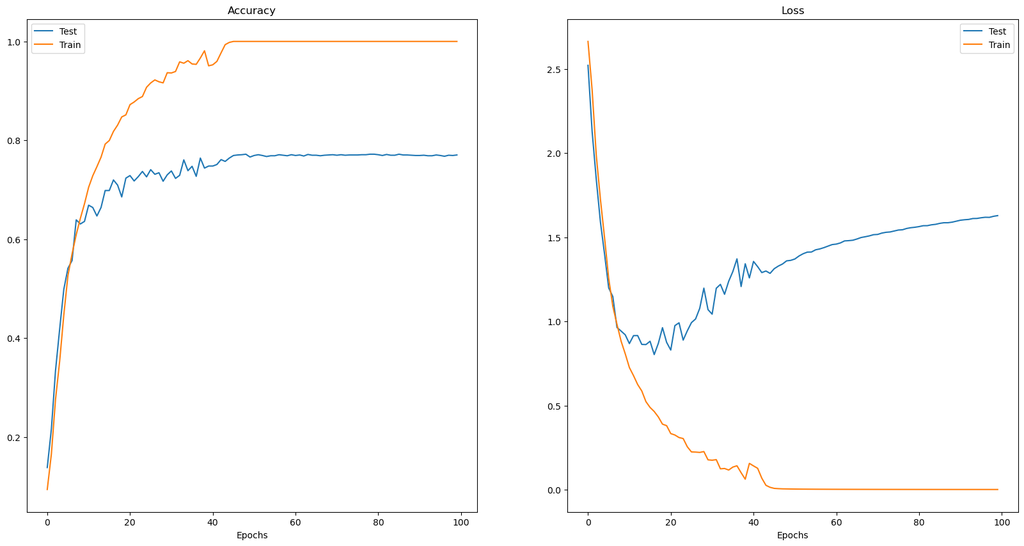

```python
plt.figure(figsize=(20,10))
plt.subplot(121)
plt.plot(range(EPOCHS), log['test_accuracy'])
plt.plot(range(EPOCHS), log['train_accuracy'])
plt.xlabel('Epochs')
plt.title('Accuracy')
plt.legend([ 'Test', 'Train'])
plt.subplot(122)
plt.plot(range(EPOCHS), log['test_loss'])
plt.plot(range(EPOCHS), log['train_loss'])
plt.xlabel('Epochs')
plt.title('Loss')
plt.legend(['Test', 'Train'])
```

قسمت دوم) وزن دهی شبکه

اگر وزن ها به صورت تصادفی مقداردهی اولیه شوند احتمال خیلی کمتری دارد که در Local minimum ها گیر کند ولی اگر وزن اولیه صفر داشته باشیم ، این احتمال خیلی بالاتر می رود. همچنین وقتی مقدار اولیه تمام وزن های شبکه برابر با صفر باشد(یا هر عدد ثابتی) مشتق ها نیز ثابت می مانند و نورون ها فقط یک سری ویژگی ها را یاد می گیرند و قاعدتا به دقت خوبی نمیرسیم و مدل نمیتواند به خوبی Predict کند.

قسمت سوم) تاثیر Learning Rate

[figure not shown]

مقادیر کوچکتر learning rate به دوره های آموزشی بیشتری نیاز دارند، با توجه به تغییرات کوچکتری که در وزن ها در هر به روزرسانی ایجاد می شود، در حالی که مقادیر بزرگ تر منجر به تغییرات سریع و نیاز به دوره های آموزشی کمتری دارد.مقادیر خیلی زیاد نیز می تواند باعث شود که مدل خیلی سریع به یک راه حل غیربهینه همگرا شود، در حالی که مقادیر بسیار کوچک می تواند باعث گیرکردن فرآیند شود.

```python
INPUT_SHAPE = 32*32
LEARNING_RATE = 0.05
EPOCHS = 100
TRAINLOADER = Dataloader(x_train, y_train, n_classes=16, batch_size=32, shuffle=True)
TESTLOADER = Dataloader(x_test, y_test, n_classes=16, batch_size=32, shuffle=True)


network = FeedForwardNN(INPUT_SHAPE)
network.add_layer(n_neurons=64, input_shape=INPUT_SHAPE, activation=Relu(), weight_initializer='uniform')
network.add_layer(n_neurons=32, input_shape=INPUT_SHAPE, activation=Relu(), weight_initializer='uniform')
network.add_layer(n_neurons=16, activation=Identical(), weight_initializer='uniform')
network.set_training_param(loss=CrossEntropy(), lr=LEARNING_RATE)

log = network.fit(EPOCHS, TRAINLOADER, TESTLOADER)
```

```
Epoch 1:
	Train: Average Accuracy: 0.059244791666666664	Average Loss: 2.9487122215287185
	Test: Average Accuracy: 0.0625	Average Loss: 2.7879286696851415
Epoch 2:
	Train: Average Accuracy: 0.05963541666666667	Average Loss: 2.7863379386158393
	Test: Average Accuracy: 0.0625	Average Loss: 2.781837494008135
Epoch 3:
	Train: Average Accuracy: 0.059244791666666664	Average Loss: 2.787379245941336
	Test: Average Accuracy: 0.0625	Average Loss: 2.781052575434839
Epoch 4:
	Train: Average Accuracy: 0.061197916666666664	Average Loss: 2.7855330135323078
	Test: Average Accuracy: 0.0625	Average Loss: 2.7858765801232623
Epoch 5:
	Train: Average Accuracy: 0.062890625	Average Loss: 2.784947477462697
	Test: Average Accuracy: 0.0625	Average Loss: 2.795008481139084
Epoch 6:
	Train: Average Accuracy: 0.060807291666666666	Average Loss: 2.786471241567938
	Test: Average Accuracy: 0.0625	Average Loss: 2.7874633779407625
Epoch 7:
	Train: Average Accuracy: 0.06276041666666667	Average Loss: 2.785623239651592
	Test: Average Accuracy: 0.0625	Average Loss: 2.78072503872181
Epoch 8:
	Train: Average Accuracy: 0.066796875	Average Loss: 2.7846252519227126
	Test: Average Accuracy: 0.0625	Average Loss: 2.7851214635259414
Epoch 9:
	Train: Average Accuracy: 0.060807291666666666	Average Loss: 2.7855354603287403
	Test: Average Accuracy: 0.0625	Average Loss: 2.786608544734805
Epoch 10:
	Train: Average Accuracy: 0.058203125	Average Loss: 2.7873203152667703
	Test: Average Accuracy: 0.0625	Average Loss: 2.789005681418566
Epoch 11:
	Train: Average Accuracy: 0.05963541666666667	Average Loss: 2.786124787496505
	Test: Average Accuracy: 0.0625	Average Loss: 2.782243831476733
Epoch 12:
	Train: Average Accuracy: 0.06145833333333333	Average Loss: 2.786360436982868
	Test: Average Accuracy: 0.0625	Average Loss: 2.783986127809868
Epoch 13:
	Train: Average Accuracy: 0.05520833333333333	Average Loss: 2.7868270166761033
	Test: Average Accuracy: 0.0625	Average Loss: 2.779131339930657
Epoch 14:
```

[output cut: 245 more lines]

```
Epoch 96:
	Train: Average Accuracy: 0.0625	Average Loss: 2.7855497516843095
	Test: Average Accuracy: 0.0625	Average Loss: 2.7807393315726694
Epoch 97:
	Train: Average Accuracy: 0.064453125	Average Loss: 2.7850918162266405
	Test: Average Accuracy: 0.0625	Average Loss: 2.777358666948095
Epoch 98:
	Train: Average Accuracy: 0.059375	Average Loss: 2.78446148224242
	Test: Average Accuracy: 0.0625	Average Loss: 2.78957937857309
Epoch 99:
	Train: Average Accuracy: 0.06536458333333334	Average Loss: 2.7839506219562917
	Test: Average Accuracy: 0.0625	Average Loss: 2.7982449124815916
Epoch 100:
	Train: Average Accuracy: 0.06197916666666667	Average Loss: 2.787582300847316
	Test: Average Accuracy: 0.0625	Average Loss: 2.7836116165936047
```

همانطور که میبینیم مقدار بزرگی برای lr انتخاب کرده ایم و باعث شده است به مقدار غیر بهینه ای برسد و دقت خوبی نداشته باشد.

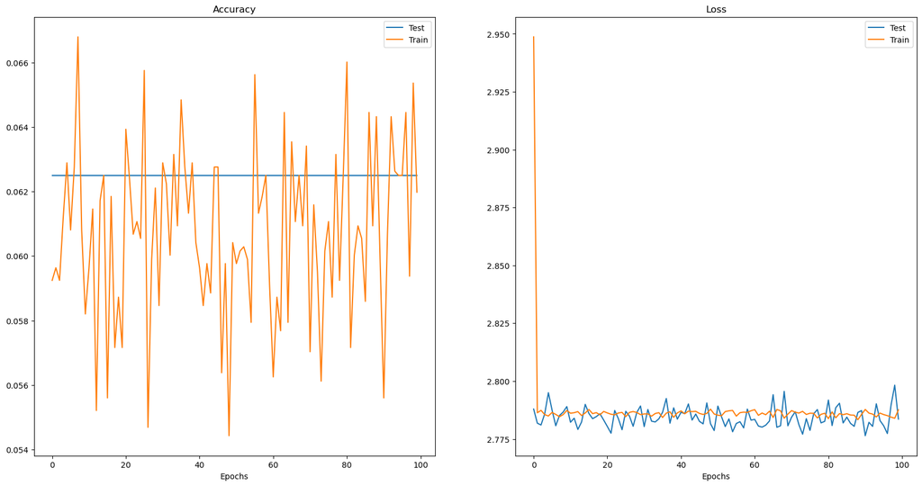

```python
plt.figure(figsize=(20,10))
plt.subplot(121)
plt.plot(range(EPOCHS), log['test_accuracy'])
plt.plot(range(EPOCHS), log['train_accuracy'])
plt.xlabel('Epochs')
plt.title('Accuracy')
plt.legend([ 'Test', 'Train'])
plt.subplot(122)
plt.plot(range(EPOCHS), log['test_loss'])
plt.plot(range(EPOCHS), log['train_loss'])
plt.xlabel('Epochs')
plt.title('Loss')
plt.legend(['Test', 'Train'])
```

```python
INPUT_SHAPE = 32*32
LEARNING_RATE = 0.0005
EPOCHS = 100
TRAINLOADER = Dataloader(x_train, y_train, n_classes=16, batch_size=32, shuffle=True)
TESTLOADER = Dataloader(x_test, y_test, n_classes=16, batch_size=32, shuffle=True)


network = FeedForwardNN(INPUT_SHAPE)
network.add_layer(n_neurons=64, input_shape=INPUT_SHAPE, activation=Relu(), weight_initializer='uniform')
network.add_layer(n_neurons=32, input_shape=INPUT_SHAPE, activation=Relu(), weight_initializer='uniform')
network.add_layer(n_neurons=16, activation=Identical(), weight_initializer='uniform')
network.set_training_param(loss=CrossEntropy(), lr=LEARNING_RATE)

log = network.fit(EPOCHS, TRAINLOADER, TESTLOADER)
```

```
Epoch 1:
	Train: Average Accuracy: 0.060807291666666666	Average Loss: 2.746671870720033
	Test: Average Accuracy: 0.0625	Average Loss: 2.742885026523359
Epoch 2:
	Train: Average Accuracy: 0.06315104166666667	Average Loss: 2.727443348188453
	Test: Average Accuracy: 0.0625	Average Loss: 2.7141381755100236
Epoch 3:
	Train: Average Accuracy: 0.062109375	Average Loss: 2.709154809328157
	Test: Average Accuracy: 0.06458333333333334	Average Loss: 2.7009381110946533
Epoch 4:
	Train: Average Accuracy: 0.07083333333333333	Average Loss: 2.6911151396578807
	Test: Average Accuracy: 0.08958333333333333	Average Loss: 2.67757433918415
Epoch 5:
	Train: Average Accuracy: 0.08138020833333333	Average Loss: 2.674533296486884
	Test: Average Accuracy: 0.096875	Average Loss: 2.6603017468306027
Epoch 6:
	Train: Average Accuracy: 0.1	Average Loss: 2.6551926607049143
	Test: Average Accuracy: 0.09010416666666667	Average Loss: 2.64449594446843
Epoch 7:
	Train: Average Accuracy: 0.11158854166666667	Average Loss: 2.6368919977274508
	Test: Average Accuracy: 0.1125	Average Loss: 2.6208430265527367
Epoch 8:
	Train: Average Accuracy: 0.123828125	Average Loss: 2.6155159151679914
	Test: Average Accuracy: 0.1109375	Average Loss: 2.600939715566553
Epoch 9:
	Train: Average Accuracy: 0.13645833333333332	Average Loss: 2.5915497065655795
	Test: Average Accuracy: 0.14166666666666666	Average Loss: 2.5697034634660745
Epoch 10:
	Train: Average Accuracy: 0.15598958333333332	Average Loss: 2.5573872872490986
	Test: Average Accuracy: 0.19895833333333332	Average Loss: 2.5257218805682724
Epoch 11:
	Train: Average Accuracy: 0.19947916666666668	Average Loss: 2.494737466051631
	Test: Average Accuracy: 0.22239583333333332	Average Loss: 2.4255275205820706
Epoch 12:
	Train: Average Accuracy: 0.20520833333333333	Average Loss: 2.3611578851173127
	Test: Average Accuracy: 0.225	Average Loss: 2.2615846817892384
Epoch 13:
	Train: Average Accuracy: 0.21979166666666666	Average Loss: 2.2293522948728546
	Test: Average Accuracy: 0.234375	Average Loss: 2.1624528006369315
Epoch 14:
```

[output cut: 245 more lines]

```
Epoch 96:
	Train: Average Accuracy: 0.7561197916666667	Average Loss: 0.6591734407710275
	Test: Average Accuracy: 0.6630208333333333	Average Loss: 0.9750851956512154
Epoch 97:
	Train: Average Accuracy: 0.7493489583333334	Average Loss: 0.6526647602286157
	Test: Average Accuracy: 0.6677083333333333	Average Loss: 0.9746398444623855
Epoch 98:
	Train: Average Accuracy: 0.7536458333333333	Average Loss: 0.6417553343710556
	Test: Average Accuracy: 0.6572916666666667	Average Loss: 0.9872491921685737
Epoch 99:
	Train: Average Accuracy: 0.759375	Average Loss: 0.6377779425911071
	Test: Average Accuracy: 0.6578125	Average Loss: 0.974802790128864
Epoch 100:
	Train: Average Accuracy: 0.7591145833333334	Average Loss: 0.6299447695766683
	Test: Average Accuracy: 0.6572916666666667	Average Loss: 0.9943334527029376
```

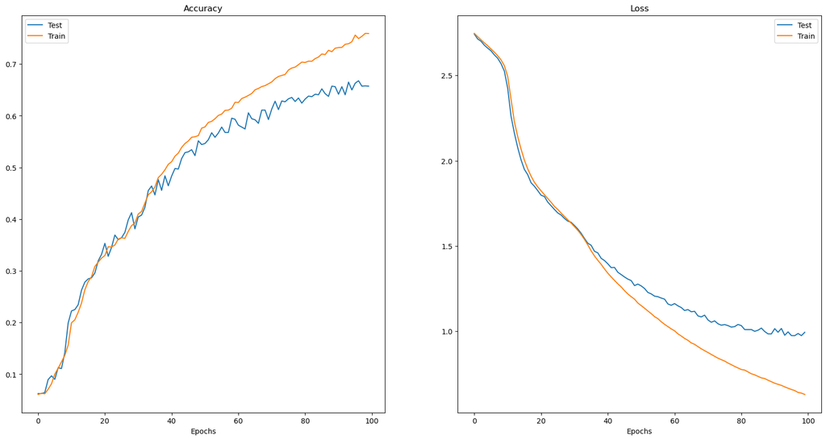

```python
plt.figure(figsize=(20,10))
plt.subplot(121)
plt.plot(range(EPOCHS), log['test_accuracy'])
plt.plot(range(EPOCHS), log['train_accuracy'])
plt.xlabel('Epochs')
plt.title('Accuracy')
plt.legend([ 'Test', 'Train'])
plt.subplot(122)
plt.plot(range(EPOCHS), log['test_loss'])
plt.plot(range(EPOCHS), log['train_loss'])
plt.xlabel('Epochs')
plt.title('Loss')
plt.legend(['Test', 'Train'])
```

با توجه به نتایج بالا می توانیم ببینیم بهینه ترین lr برابر است با 0.005.

قسمت چهارم) تاثیر Activation Function

```python
INPUT_SHAPE = 32*32
LEARNING_RATE = 0.005
EPOCHS = 100
TRAINLOADER = Dataloader(x_train, y_train, n_classes=16, batch_size=32, shuffle=True)
TESTLOADER = Dataloader(x_test, y_test, n_classes=16, batch_size=32, shuffle=True)


network = FeedForwardNN(INPUT_SHAPE)
network.add_layer(n_neurons=64, input_shape=INPUT_SHAPE, activation=Sigmoid(), weight_initializer='uniform')
network.add_layer(n_neurons=32, input_shape=INPUT_SHAPE, activation=Sigmoid(), weight_initializer='uniform')
network.add_layer(n_neurons=16, activation=Identical(), weight_initializer='uniform')
network.set_training_param(loss=CrossEntropy(), lr=LEARNING_RATE)

log = network.fit(EPOCHS, TRAINLOADER, TESTLOADER)
```

```
Epoch 1:
	Train: Average Accuracy: 0.06484375	Average Loss: 2.7944927746193455
	Test: Average Accuracy: 0.0625	Average Loss: 2.7828839312179725
Epoch 2:
	Train: Average Accuracy: 0.059375	Average Loss: 2.788679588135577
	Test: Average Accuracy: 0.0625	Average Loss: 2.7909799102490473
Epoch 3:
	Train: Average Accuracy: 0.06354166666666666	Average Loss: 2.7840261538361477
	Test: Average Accuracy: 0.0625	Average Loss: 2.7750115517698855
Epoch 4:
	Train: Average Accuracy: 0.07096354166666667	Average Loss: 2.7705375167339015
	Test: Average Accuracy: 0.10989583333333333	Average Loss: 2.755050930714709
Epoch 5:
	Train: Average Accuracy: 0.08802083333333334	Average Loss: 2.749889597842521
	Test: Average Accuracy: 0.12760416666666666	Average Loss: 2.7351788716401506
Epoch 6:
	Train: Average Accuracy: 0.10494791666666667	Average Loss: 2.7245113931711686
	Test: Average Accuracy: 0.10729166666666666	Average Loss: 2.7065428110710226
Epoch 7:
	Train: Average Accuracy: 0.10729166666666666	Average Loss: 2.692872180659616
	Test: Average Accuracy: 0.11145833333333334	Average Loss: 2.6753632549129946
Epoch 8:
	Train: Average Accuracy: 0.11236979166666666	Average Loss: 2.65246535439558
	Test: Average Accuracy: 0.09270833333333334	Average Loss: 2.633583160374327
Epoch 9:
	Train: Average Accuracy: 0.117578125	Average Loss: 2.6065577813473886
	Test: Average Accuracy: 0.14010416666666667	Average Loss: 2.5755507503444246
Epoch 10:
	Train: Average Accuracy: 0.11966145833333333	Average Loss: 2.554742067003397
	Test: Average Accuracy: 0.13489583333333333	Average Loss: 2.5198054512673735
Epoch 11:
	Train: Average Accuracy: 0.1171875	Average Loss: 2.5074566611651194
	Test: Average Accuracy: 0.121875	Average Loss: 2.4723334844881917
Epoch 12:
	Train: Average Accuracy: 0.12721354166666668	Average Loss: 2.4637293132264744
	Test: Average Accuracy: 0.13333333333333333	Average Loss: 2.4349144498704107
Epoch 13:
	Train: Average Accuracy: 0.12096354166666666	Average Loss: 2.4263456322210972
	Test: Average Accuracy: 0.13854166666666667	Average Loss: 2.403706058833206
Epoch 14:
```

[output cut: 245 more lines]

```
Epoch 96:
	Train: Average Accuracy: 0.877734375	Average Loss: 0.37008296709754845
	Test: Average Accuracy: 0.7135416666666666	Average Loss: 0.8305094994686674
Epoch 97:
	Train: Average Accuracy: 0.8807291666666667	Average Loss: 0.3619644172063486
	Test: Average Accuracy: 0.7161458333333334	Average Loss: 0.8136933494921937
Epoch 98:
	Train: Average Accuracy: 0.8856770833333333	Average Loss: 0.35309219628077865
	Test: Average Accuracy: 0.7083333333333334	Average Loss: 0.8472633225952123
Epoch 99:
	Train: Average Accuracy: 0.88671875	Average Loss: 0.3431895977840151
	Test: Average Accuracy: 0.7114583333333333	Average Loss: 0.8303041507510495
Epoch 100:
	Train: Average Accuracy: 0.894921875	Average Loss: 0.33484440470714755
	Test: Average Accuracy: 0.7213541666666666	Average Loss: 0.8250145909218046
```

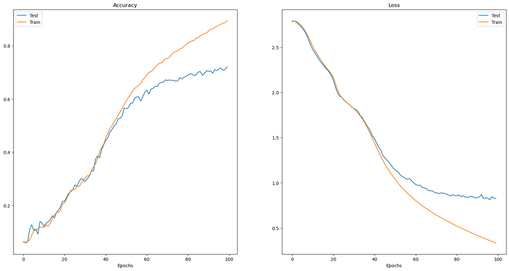

```python
plt.figure(figsize=(20,10))
plt.subplot(121)
plt.plot(range(EPOCHS), log['test_accuracy'])
plt.plot(range(EPOCHS), log['train_accuracy'])
plt.xlabel('Epochs')
plt.title('Accuracy')
plt.legend([ 'Test', 'Train'])
plt.subplot(122)
plt.plot(range(EPOCHS), log['test_loss'])
plt.plot(range(EPOCHS), log['train_loss'])
plt.xlabel('Epochs')
plt.title('Loss')
plt.legend(['Test', 'Train'])
```

```python
INPUT_SHAPE = 32*32
LEARNING_RATE = 0.005
EPOCHS = 100
TRAINLOADER = Dataloader(x_train, y_train, n_classes=16, batch_size=32, shuffle=True)
TESTLOADER = Dataloader(x_test, y_test, n_classes=16, batch_size=32, shuffle=True)


network = FeedForwardNN(INPUT_SHAPE)
network.add_layer(n_neurons=64, input_shape=INPUT_SHAPE, activation=Tanh(), weight_initializer='uniform')
network.add_layer(n_neurons=32, input_shape=INPUT_SHAPE, activation=Tanh(), weight_initializer='uniform')
network.add_layer(n_neurons=16, activation=Identical(), weight_initializer='uniform')
network.set_training_param(loss=CrossEntropy(), lr=LEARNING_RATE)

log = network.fit(EPOCHS, TRAINLOADER, TESTLOADER)
```

```
Epoch 1:
	Train: Average Accuracy: 0.07239583333333334	Average Loss: 2.755178064797506
	Test: Average Accuracy: 0.12083333333333333	Average Loss: 2.6646497986886506
Epoch 2:
	Train: Average Accuracy: 0.123046875	Average Loss: 2.475146711395173
	Test: Average Accuracy: 0.13229166666666667	Average Loss: 2.3282949598594596
Epoch 3:
	Train: Average Accuracy: 0.19518229166666667	Average Loss: 2.196228332369853
	Test: Average Accuracy: 0.28177083333333336	Average Loss: 1.965211594904919
Epoch 4:
	Train: Average Accuracy: 0.299609375	Average Loss: 1.852851711701384
	Test: Average Accuracy: 0.31875	Average Loss: 1.8000018941598128
Epoch 5:
	Train: Average Accuracy: 0.356640625	Average Loss: 1.6593196268316708
	Test: Average Accuracy: 0.38958333333333334	Average Loss: 1.5798632245712319
Epoch 6:
	Train: Average Accuracy: 0.43216145833333336	Average Loss: 1.437073884108501
	Test: Average Accuracy: 0.4432291666666667	Average Loss: 1.3617331722601114
Epoch 7:
	Train: Average Accuracy: 0.5104166666666666	Average Loss: 1.2350621438158464
	Test: Average Accuracy: 0.5510416666666667	Average Loss: 1.1887995929004866
Epoch 8:
	Train: Average Accuracy: 0.5701822916666667	Average Loss: 1.0814669187399806
	Test: Average Accuracy: 0.5807291666666666	Average Loss: 1.1195952187004303
Epoch 9:
	Train: Average Accuracy: 0.616015625	Average Loss: 0.9670007511696513
	Test: Average Accuracy: 0.6302083333333334	Average Loss: 1.0040118712359212
Epoch 10:
	Train: Average Accuracy: 0.6625	Average Loss: 0.8603995218504564
	Test: Average Accuracy: 0.6567708333333333	Average Loss: 0.9267929464641338
Epoch 11:
	Train: Average Accuracy: 0.6904947916666667	Average Loss: 0.7832113088746258
	Test: Average Accuracy: 0.6411458333333333	Average Loss: 0.9344709910042363
Epoch 12:
	Train: Average Accuracy: 0.7162760416666667	Average Loss: 0.7146993954842685
	Test: Average Accuracy: 0.6609375	Average Loss: 0.8849073199760983
Epoch 13:
	Train: Average Accuracy: 0.741015625	Average Loss: 0.6523173643316516
	Test: Average Accuracy: 0.6723958333333333	Average Loss: 0.8747286353797425
Epoch 14:
```

[output cut: 245 more lines]

```
Epoch 96:
	Train: Average Accuracy: 1.0	Average Loss: 0.0035745469038820374
	Test: Average Accuracy: 0.76875	Average Loss: 1.1669025105039532
Epoch 97:
	Train: Average Accuracy: 1.0	Average Loss: 0.003503853975321799
	Test: Average Accuracy: 0.7671875	Average Loss: 1.1657279673524668
Epoch 98:
	Train: Average Accuracy: 1.0	Average Loss: 0.0034504598059081127
	Test: Average Accuracy: 0.7671875	Average Loss: 1.1711638340791792
Epoch 99:
	Train: Average Accuracy: 1.0	Average Loss: 0.003391963170488178
	Test: Average Accuracy: 0.7682291666666666	Average Loss: 1.1710820776417494
Epoch 100:
	Train: Average Accuracy: 1.0	Average Loss: 0.0033341006330438517
	Test: Average Accuracy: 0.7671875	Average Loss: 1.1771090255108427
```

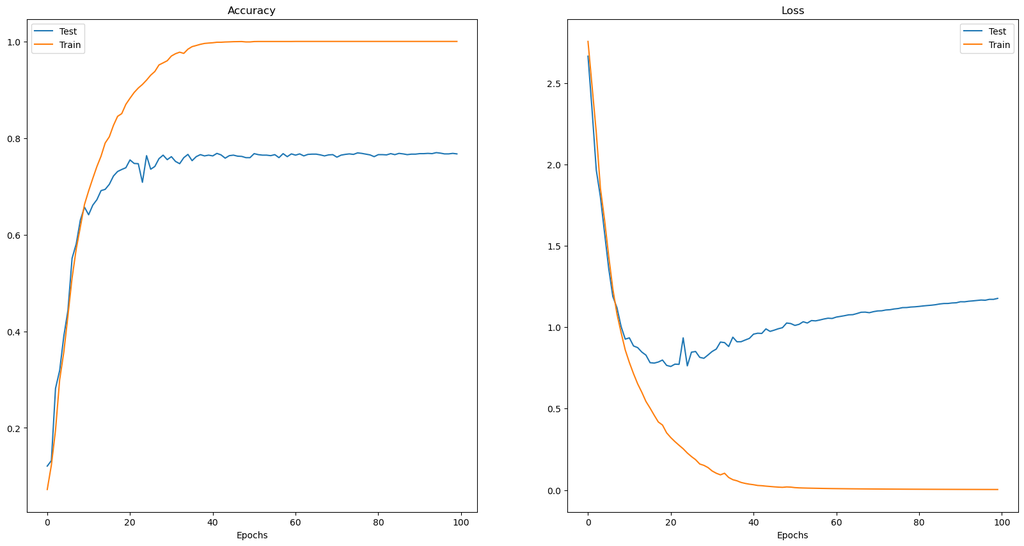

```python
plt.figure(figsize=(20,10))
plt.subplot(121)
plt.plot(range(EPOCHS), log['test_accuracy'])
plt.plot(range(EPOCHS), log['train_accuracy'])
plt.xlabel('Epochs')
plt.title('Accuracy')
plt.legend([ 'Test', 'Train'])
plt.subplot(122)
plt.plot(range(EPOCHS), log['test_loss'])
plt.plot(range(EPOCHS), log['train_loss'])
plt.xlabel('Epochs')
plt.title('Loss')
plt.legend(['Test', 'Train'])
```

```python
INPUT_SHAPE = 32*32
LEARNING_RATE = 0.005
EPOCHS = 100
TRAINLOADER = Dataloader(x_train, y_train, n_classes=16, batch_size=32, shuffle=True)
TESTLOADER = Dataloader(x_test, y_test, n_classes=16, batch_size=32, shuffle=True)


network = FeedForwardNN(INPUT_SHAPE)
network.add_layer(n_neurons=64, input_shape=INPUT_SHAPE, activation=LeakyRelu(), weight_initializer='uniform')
network.add_layer(n_neurons=32, input_shape=INPUT_SHAPE, activation=LeakyRelu(), weight_initializer='uniform')
network.add_layer(n_neurons=16, activation=Identical(), weight_initializer='uniform')
network.set_training_param(loss=CrossEntropy(), lr=LEARNING_RATE)

log = network.fit(EPOCHS, TRAINLOADER, TESTLOADER)
```

```
Epoch 1:
	Train: Average Accuracy: 0.09322916666666667	Average Loss: 2.6858651635472404
	Test: Average Accuracy: 0.12708333333333333	Average Loss: 2.5461650780485434
Epoch 2:
	Train: Average Accuracy: 0.1421875	Average Loss: 2.433372399724197
	Test: Average Accuracy: 0.24322916666666666	Average Loss: 2.0694058035340976
Epoch 3:
	Train: Average Accuracy: 0.262109375	Average Loss: 2.0150592928808275
	Test: Average Accuracy: 0.29010416666666666	Average Loss: 1.8718907658924238
Epoch 4:
	Train: Average Accuracy: 0.321875	Average Loss: 1.8308520087927214
	Test: Average Accuracy: 0.3489583333333333	Average Loss: 1.72495736273951
Epoch 5:
	Train: Average Accuracy: 0.3776041666666667	Average Loss: 1.6286004137596686
	Test: Average Accuracy: 0.38125	Average Loss: 1.5875833569106492
Epoch 6:
	Train: Average Accuracy: 0.435546875	Average Loss: 1.4344965919861654
	Test: Average Accuracy: 0.40625	Average Loss: 1.4587991912790734
Epoch 7:
	Train: Average Accuracy: 0.505078125	Average Loss: 1.2550681697529678
	Test: Average Accuracy: 0.5208333333333334	Average Loss: 1.2123915389722582
Epoch 8:
	Train: Average Accuracy: 0.554296875	Average Loss: 1.103659140618556
	Test: Average Accuracy: 0.5640625	Average Loss: 1.1279272595873515
Epoch 9:
	Train: Average Accuracy: 0.6018229166666667	Average Loss: 0.9816629334537768
	Test: Average Accuracy: 0.5536458333333333	Average Loss: 1.1312636123595559
Epoch 10:
	Train: Average Accuracy: 0.6326822916666667	Average Loss: 0.8958752843400701
	Test: Average Accuracy: 0.6	Average Loss: 1.0545219293981498
Epoch 11:
	Train: Average Accuracy: 0.6669270833333333	Average Loss: 0.8166283048736178
	Test: Average Accuracy: 0.63125	Average Loss: 0.9283729432350082
Epoch 12:
	Train: Average Accuracy: 0.690234375	Average Loss: 0.7550153816523806
	Test: Average Accuracy: 0.6479166666666667	Average Loss: 0.9447396634222327
Epoch 13:
	Train: Average Accuracy: 0.711328125	Average Loss: 0.7015416930125636
	Test: Average Accuracy: 0.653125	Average Loss: 0.9182178763331846
Epoch 14:
```

[output cut: 245 more lines]

```
Epoch 96:
	Train: Average Accuracy: 1.0	Average Loss: 0.0008672294736397998
	Test: Average Accuracy: 0.7713541666666667	Average Loss: 1.6027550812529674
Epoch 97:
	Train: Average Accuracy: 1.0	Average Loss: 0.0008508357085918681
	Test: Average Accuracy: 0.771875	Average Loss: 1.6044848761429968
Epoch 98:
	Train: Average Accuracy: 1.0	Average Loss: 0.0008350188886361531
	Test: Average Accuracy: 0.7703125	Average Loss: 1.611519184777028
Epoch 99:
	Train: Average Accuracy: 1.0	Average Loss: 0.0008225650402442793
	Test: Average Accuracy: 0.771875	Average Loss: 1.6109385850711406
Epoch 100:
	Train: Average Accuracy: 1.0	Average Loss: 0.0008082099334041676
	Test: Average Accuracy: 0.7708333333333334	Average Loss: 1.6152945332268742
```

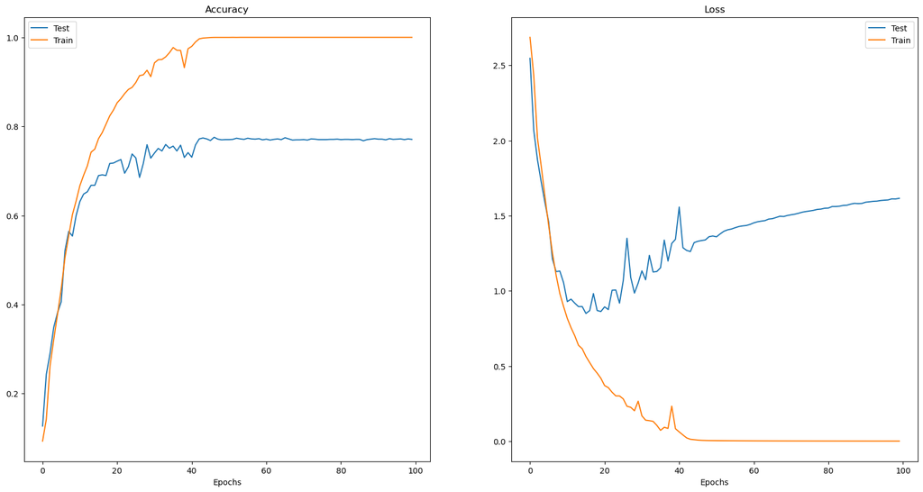

```python
plt.figure(figsize=(20,10))
plt.subplot(121)
plt.plot(range(EPOCHS), log['test_accuracy'])
plt.plot(range(EPOCHS), log['train_accuracy'])
plt.xlabel('Epochs')
plt.title('Accuracy')
plt.legend([ 'Test', 'Train'])
plt.subplot(122)
plt.plot(range(EPOCHS), log['test_loss'])
plt.plot(range(EPOCHS), log['train_loss'])
plt.xlabel('Epochs')
plt.title('Loss')
plt.legend(['Test', 'Train'])
```

مقادیر دقت روی تست : Relu : 0.7703125 Sigmoid : 0.7213541666666666 Tanh : 0.7671875 LeakyRelu : 0.7708333333333334 همانطور که می بینیم کمترین دقت متعلق به Sigmoid است و همچنین Tanh نیز دقت کمتری نسبت به Relu و LeakyRelu دارد. وقتی به دو تابع Sigmoid و Tanh مقدار بسیار زیاد یا بسیار کمی می دهیم، مشتق هر دوی آنها تقریبا برابر با صفر می شود، بنابراین در هنگام آموزش مدل هنگام آپدیت کردن، تاثیر مشتق برای این توابع صفر می شود و مدل ما به درستی آموزش نمی بیند. بنابراین این دوتابع عملکرد مناسبی برای این دست شبکه ها ندارند. هنگام استفاده از Relu ممکن است به مشکل Dead Relu برخورد کنیم که در آن بعضی نورون ها ممکن است هیچگاه فعال نشوند و در نتیجه وزن هایی که به خروجی این نورون نسبت داده می‌شوند هیچگاه به روز رسانی نشوند. برای حل این مشکل از LeakyRelu استفاده می‌کنیم که دقیقا شبیه تابع Relu است با این تفاوت که به جای نسبت دادن ۰ به ورودی های منفی، کسر کوچکی از این عدد منفی را به عنوان خروجی اعداد منفی انتخاب می‌کند. وقتی از تابع Relu استفاده می کنیم به مشکل Dead Relu برخورد می کنیم. به این معنی است که در آن بعضی از نورون ها ممکن است خاموش باشند و وزن های این نورون ها هیچ وقت آپدیت نمی شوند. برای حل این مشکل از LeakyRelu استفاده می کنیم به این شکل که وقتی ورودی های منفی می گیرد، بجای خروجی صفر(تابع Relu) یک عدد کسری کوچک منفی به عنوان خروجی می دهد. پس بهترین Activation Function در اینجا leakyRelu می باشد.

قسمت پنجم) تاثیر Batch Size

```python
INPUT_SHAPE = 32*32
LEARNING_RATE = 0.005
EPOCHS = 100
TRAINLOADER = Dataloader(x_train, y_train, n_classes=16, batch_size=16, shuffle=True)
TESTLOADER = Dataloader(x_test, y_test, n_classes=16, batch_size=16, shuffle=True)


network = FeedForwardNN(INPUT_SHAPE)
network.add_layer(n_neurons=64, input_shape=INPUT_SHAPE, activation=LeakyRelu(), weight_initializer='uniform')
network.add_layer(n_neurons=32, input_shape=INPUT_SHAPE, activation=LeakyRelu(), weight_initializer='uniform')
network.add_layer(n_neurons=16, activation=Identical(), weight_initializer='uniform')
network.set_training_param(loss=CrossEntropy(), lr=LEARNING_RATE)

log = network.fit(EPOCHS, TRAINLOADER, TESTLOADER)
```

```
Epoch 1:
	Train: Average Accuracy: 0.094140625	Average Loss: 2.659262352509356
	Test: Average Accuracy: 0.12708333333333333	Average Loss: 2.520615558736922
Epoch 2:
	Train: Average Accuracy: 0.20182291666666666	Average Loss: 2.2697132926969132
	Test: Average Accuracy: 0.26458333333333334	Average Loss: 1.9813284936225908
Epoch 3:
	Train: Average Accuracy: 0.301171875	Average Loss: 1.9006927359005317
	Test: Average Accuracy: 0.334375	Average Loss: 1.7924283606612321
Epoch 4:
	Train: Average Accuracy: 0.36861979166666664	Average Loss: 1.6746241136176343
	Test: Average Accuracy: 0.403125	Average Loss: 1.5627622977238294
Epoch 5:
	Train: Average Accuracy: 0.4596354166666667	Average Loss: 1.4495464192311653
	Test: Average Accuracy: 0.5151041666666667	Average Loss: 1.3114626570152796
Epoch 6:
	Train: Average Accuracy: 0.5342447916666667	Average Loss: 1.2318757119325479
	Test: Average Accuracy: 0.5239583333333333	Average Loss: 1.2733736390880126
Epoch 7:
	Train: Average Accuracy: 0.5747395833333333	Average Loss: 1.0879046251741398
	Test: Average Accuracy: 0.5927083333333333	Average Loss: 1.0533863592877384
Epoch 8:
	Train: Average Accuracy: 0.6111979166666667	Average Loss: 0.983286259107049
	Test: Average Accuracy: 0.6130208333333333	Average Loss: 0.9988923719357593
Epoch 9:
	Train: Average Accuracy: 0.6358072916666667	Average Loss: 0.9082466155401029
	Test: Average Accuracy: 0.6255208333333333	Average Loss: 0.9688627873806878
Epoch 10:
	Train: Average Accuracy: 0.6717447916666667	Average Loss: 0.8159900783934564
	Test: Average Accuracy: 0.6541666666666667	Average Loss: 0.9062170905298447
Epoch 11:
	Train: Average Accuracy: 0.6946614583333334	Average Loss: 0.7588170453877827
	Test: Average Accuracy: 0.6359375	Average Loss: 0.9695208492465092
Epoch 12:
	Train: Average Accuracy: 0.7213541666666666	Average Loss: 0.6934958128853594
	Test: Average Accuracy: 0.6744791666666666	Average Loss: 0.8854444825293858
Epoch 13:
	Train: Average Accuracy: 0.739453125	Average Loss: 0.636113158995742
	Test: Average Accuracy: 0.6739583333333333	Average Loss: 0.9020151786824482
Epoch 14:
```

[output cut: 245 more lines]

```
Epoch 96:
	Train: Average Accuracy: 1.0	Average Loss: 0.0007537336059508122
	Test: Average Accuracy: 0.7651041666666667	Average Loss: 1.7217022076889517
Epoch 97:
	Train: Average Accuracy: 1.0	Average Loss: 0.0007414283810072262
	Test: Average Accuracy: 0.7645833333333333	Average Loss: 1.7226636541403288
Epoch 98:
	Train: Average Accuracy: 1.0	Average Loss: 0.0007280712870417853
	Test: Average Accuracy: 0.7645833333333333	Average Loss: 1.7284628541710765
Epoch 99:
	Train: Average Accuracy: 1.0	Average Loss: 0.0007171995308402657
	Test: Average Accuracy: 0.7640625	Average Loss: 1.728101888693735
Epoch 100:
	Train: Average Accuracy: 1.0	Average Loss: 0.0007055972261176907
	Test: Average Accuracy: 0.765625	Average Loss: 1.7314701179536514
```

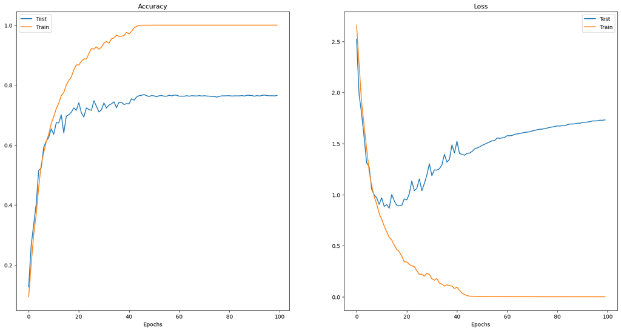

```python
plt.figure(figsize=(20,10))
plt.subplot(121)
plt.plot(range(EPOCHS), log['test_accuracy'])
plt.plot(range(EPOCHS), log['train_accuracy'])
plt.xlabel('Epochs')
plt.title('Accuracy')
plt.legend([ 'Test', 'Train'])
plt.subplot(122)
plt.plot(range(EPOCHS), log['test_loss'])
plt.plot(range(EPOCHS), log['train_loss'])
plt.xlabel('Epochs')
plt.title('Loss')
plt.legend(['Test', 'Train'])
```

```python
INPUT_SHAPE = 32*32
LEARNING_RATE = 0.005
EPOCHS = 100
TRAINLOADER = Dataloader(x_train, y_train, n_classes=16, batch_size=256, shuffle=True)
TESTLOADER = Dataloader(x_test, y_test, n_classes=16, batch_size=256, shuffle=True)


network = FeedForwardNN(INPUT_SHAPE)
network.add_layer(n_neurons=64, input_shape=INPUT_SHAPE, activation=LeakyRelu(), weight_initializer='uniform')
network.add_layer(n_neurons=32, input_shape=INPUT_SHAPE, activation=LeakyRelu(), weight_initializer='uniform')
network.add_layer(n_neurons=16, activation=Identical(), weight_initializer='uniform')
network.set_training_param(loss=CrossEntropy(), lr=LEARNING_RATE)

log = network.fit(EPOCHS, TRAINLOADER, TESTLOADER)
```

```
Epoch 1:
	Train: Average Accuracy: 0.052994791666666666	Average Loss: 2.9041458708582786
	Test: Average Accuracy: 0.068359375	Average Loss: 2.7707286802110818
Epoch 2:
	Train: Average Accuracy: 0.06927083333333334	Average Loss: 2.761283200086368
	Test: Average Accuracy: 0.0703125	Average Loss: 2.751567865258977
Epoch 3:
	Train: Average Accuracy: 0.07760416666666667	Average Loss: 2.742553264218888
	Test: Average Accuracy: 0.07568359375	Average Loss: 2.733405102152441
Epoch 4:
	Train: Average Accuracy: 0.08385416666666666	Average Loss: 2.7244144889176583
	Test: Average Accuracy: 0.12744140625	Average Loss: 2.7143761360839807
Epoch 5:
	Train: Average Accuracy: 0.10703125	Average Loss: 2.704378684636012
	Test: Average Accuracy: 0.09912109375	Average Loss: 2.695958786186105
Epoch 6:
	Train: Average Accuracy: 0.11731770833333334	Average Loss: 2.6824232238252828
	Test: Average Accuracy: 0.1181640625	Average Loss: 2.67149688439068
Epoch 7:
	Train: Average Accuracy: 0.11653645833333333	Average Loss: 2.6574307449285746
	Test: Average Accuracy: 0.11962890625	Average Loss: 2.6438238457420438
Epoch 8:
	Train: Average Accuracy: 0.12057291666666667	Average Loss: 2.6309402513400513
	Test: Average Accuracy: 0.11865234375	Average Loss: 2.6175172533980837
Epoch 9:
	Train: Average Accuracy: 0.12864583333333332	Average Loss: 2.6032374893496146
	Test: Average Accuracy: 0.12548828125	Average Loss: 2.5896086742274846
Epoch 10:
	Train: Average Accuracy: 0.128125	Average Loss: 2.573931817977187
	Test: Average Accuracy: 0.1279296875	Average Loss: 2.5621299569212477
Epoch 11:
	Train: Average Accuracy: 0.13294270833333333	Average Loss: 2.5469040013386115
	Test: Average Accuracy: 0.13916015625	Average Loss: 2.5332416821579655
Epoch 12:
	Train: Average Accuracy: 0.13997395833333334	Average Loss: 2.5206867123059955
	Test: Average Accuracy: 0.134765625	Average Loss: 2.5114894860102437
Epoch 13:
	Train: Average Accuracy: 0.13776041666666666	Average Loss: 2.498225645418371
	Test: Average Accuracy: 0.1396484375	Average Loss: 2.4891198196366897
Epoch 14:
```

[output cut: 245 more lines]

```
Epoch 96:
	Train: Average Accuracy: 0.6036458333333333	Average Loss: 0.9084198976899177
	Test: Average Accuracy: 0.52490234375	Average Loss: 1.2340017164740908
Epoch 97:
	Train: Average Accuracy: 0.5352864583333333	Average Loss: 1.1504916014538573
	Test: Average Accuracy: 0.49658203125	Average Loss: 1.3363118789528174
Epoch 98:
	Train: Average Accuracy: 0.5934895833333333	Average Loss: 0.9536354164796834
	Test: Average Accuracy: 0.50439453125	Average Loss: 1.260367979295398
Epoch 99:
	Train: Average Accuracy: 0.61484375	Average Loss: 0.8842019109942421
	Test: Average Accuracy: 0.529296875	Average Loss: 1.2378785954612805
Epoch 100:
	Train: Average Accuracy: 0.6169270833333333	Average Loss: 0.9076504225847569
	Test: Average Accuracy: 0.52099609375	Average Loss: 1.2596121303089163
```

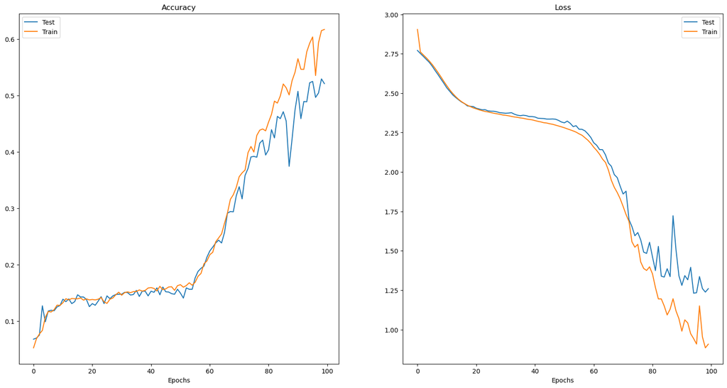

```python
plt.figure(figsize=(20,10))
plt.subplot(121)
plt.plot(range(EPOCHS), log['test_accuracy'])
plt.plot(range(EPOCHS), log['train_accuracy'])
plt.xlabel('Epochs')
plt.title('Accuracy')
plt.legend([ 'Test', 'Train'])
plt.subplot(122)
plt.plot(range(EPOCHS), log['test_loss'])
plt.plot(range(EPOCHS), log['train_loss'])
plt.xlabel('Epochs')
plt.title('Loss')
plt.legend(['Test', 'Train'])
```

وقتی batch size برابر با 16 است دقت مدل به مقدار کمی کاهش پیدا می کند و زمان بیشتری برای آموزش طول می کشد. وقتی batch size برابر با 256 است دقت مدل به شدت کاهش می یابد ولی زمان کوتاهی برای آموزش طول می کشد و سرعت آن افزایش پیدا می کند. با استفاده کردن از batch چون هنگام آموزش از نمونه های کمتری استفاده می کنیم بنابراین از مموری کمتری استفاده می کنیم. این موضوع وقتی خیلی ضروری می شود که ما برای ذخیره تمام دیتای آموزشی به اندازه کافی مموری نداشته باشیم. همچنین چون بعد از Propagation، وزن ها را آپدیت می کنیم پس استفاده از batch باعث می شود سرعت آموزش مدل بالاتر برود. وقتی مقدار batch ما خیلی کوچک باشد زمان خیلی زیادی به آموزش نیاز دارد. وقتی مقدار batch ما خیلی بزرگ باشد مموری زیادی نیاز دارد و دقت کاهش پیدا می کند.